# CHAPTER 9: VISUALISATION IN R

```r
dt <- read.csv("C:\\Users\\user\\OneDrive\\Desktop\\Sem4 slide\\data science programming 2\\dt_clean.csv", header=TRUE)
dt
```

| Section | ID_no | Gender | weight | height | bmi | categories |
| --- | --- | --- | --- | --- | --- | --- |
| Section 02G | 1001 |  | 50.0 | 1.70 | 17.30104 | Underweight |
| Section 01G | 1002 | Female | 72.0 | 1.66 | 26.12861 | Overweight |
| Section 02G | 1003 | Female | 55.0 | 1.60 | 21.48438 | Normal |
| Section 01G | 1004 | Female | 53.9 | 1.56 | 22.14826 | Normal |
| Section 01G | 1005 | Female | 72.0 | 1.60 | 28.12500 | Overweight |
| Section 01G | 1006 | Female | 78.0 | 1.56 | 32.05128 | Obese |
| Section 02G | 1007 | Male | 71.0 | 1.79 | 22.15911 | Normal |
| Section 01G | 1008 | Female | 46.0 | 1.61 | 17.74623 | Underweight |
| Section 01G | 1009 | Male | 55.0 | 1.84 | 16.24527 | Underweight |
| Section 01G | 1010 | Female | 57.0 | 1.65 | 20.93664 | Normal |

[output cut: 61 more lines]

1. Bar Plot • Bar plots are very useful to represent the count of any categorical variables.

• Other related graphs for categorical data in R are spine plots or mosaic plots.

Example 9.1 Bar Plot

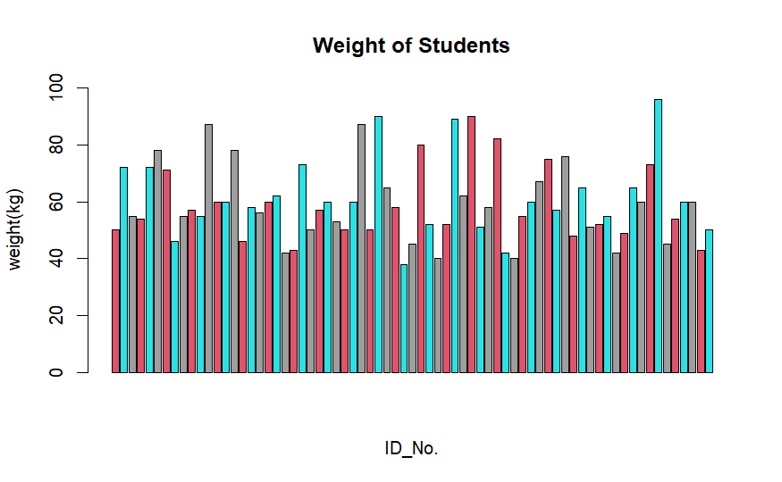

```r
## Barplot
barplot(dt$weight, ylim=c(0,100),names=dt$ID_No,
ylab="weight(kg)", xlab="ID_No.",
main="Weight of Students", col=c(2,5,8))
```

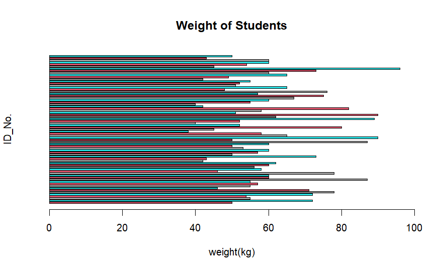

```r
barplot(dt$weight, xlim=c(0,100),
horiz=TRUE, names=dt$ID_No,
ylab="ID_No.", xlab="weight(kg)",
main="Weight of Students", col=c(2,5,8))
```

2. Dot Plot • A Dot Plot is a graphical display of data using dots plotted on a graph with an x-axis and y-axis.

• A dot plot is also known as a strip plot or dot chart.

• These types of charts are used to graphically depict certain data trends or groupings.

Example 9.2 Dot Plot

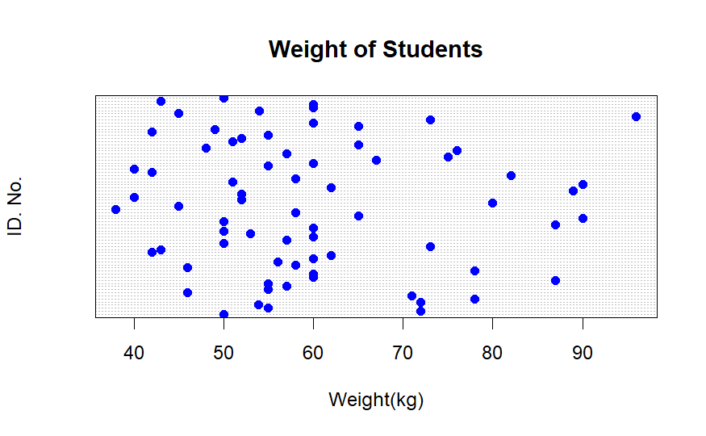

```r
## Dot chart
dotchart(dt$weight, ylim=c(0,100),labels=dt$ID_No,
xlab="Weight(kg)", ylab="ID. No.",
main="Weight of Students", col='blue', pch=16, cex=1.2)
```

3. Pie Chart • A pie chart, also known as a circle chart, is a circular diagram that resembles a pie.

• A pie chart shows how a total amount is divided between levels of a categorical variable as a circle divided into radial slices.

Example 9.3 Pie Chart

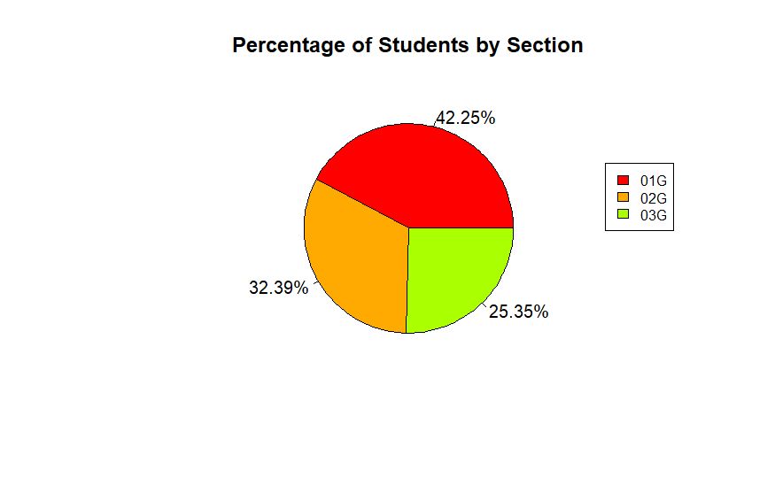

```r
## Pie chart
# Calculate the percentage for each section

freq_section <- round(prop.table(table(dt$Section))*100, 2)

section_labels <- round(prop.table(table(dt$Section))*100, 2)

# Concatenate a ’%’ char after each value
section_labels <- paste(section_labels, "%", sep="")

pie(freq_section, labels=section_labels, col = rainbow(9),
    main="Percentage of Students by Section")

# Create a legend at the right
legend(1.5, 0.5, c("01G","02G","03G"), cex=0.8,
fill=rainbow(9))
```

4. Histogram • Histogram shows how the data is distributed.

• It helps to understand the underlying statistical distribution of the data.

• The shape of distribution of data can either be symmetric or skewed.

• Also can detect the existence of outliers.

Example 9.4a Histogram

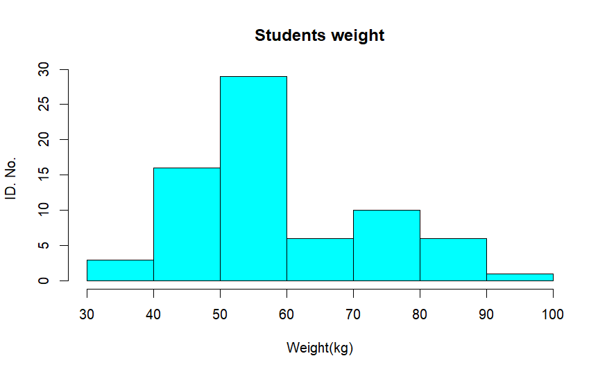

```r
## Histogram
hist(dt$weight, xlab="Weight(kg)", ylab="ID. No.",
main="Students weight", col="cyan")
```

Example 9.4b Histogram and Density

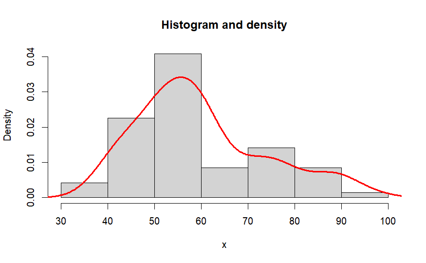

```r
x <- dt$weight
hist(x, freq = FALSE, main = "Histogram and density")

# Calculate density
dx <- density(dt$weight)

# Add density
lines(dx, lwd = 3, col = "red") ##ecdf
```

5. Box plots • Box plots are designed to represent some characteristics of the data like dispersion or skewness and also to identify outliers.

• Box plot is also known as box and whiskers plot.

• It presents five number summary which include minimum value, quartiles (first, second and third) and the maximum value.

• The location of medium in the box will determine the skewness of the data distribution. If it is located in the middle, then the data is symmetric. If the medium is close to the first quartile, the data is right skewed. Otherwise, the data is left skewed.

• The box plot also shows the existence of outliers.

Example 9.5a Box Plots

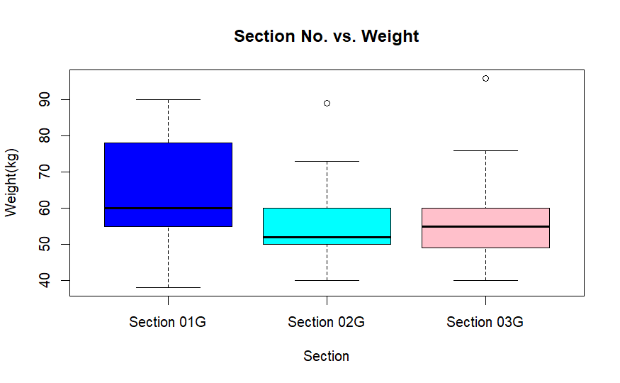

```r
## Box plot
boxplot(dt$weight~dt$Section,xlab="Section",ylab="Weight(kg)",
main="Section No. vs. Weight", col=c("blue","cyan","pink"))
```

Example 9.5b Notch Box Plots

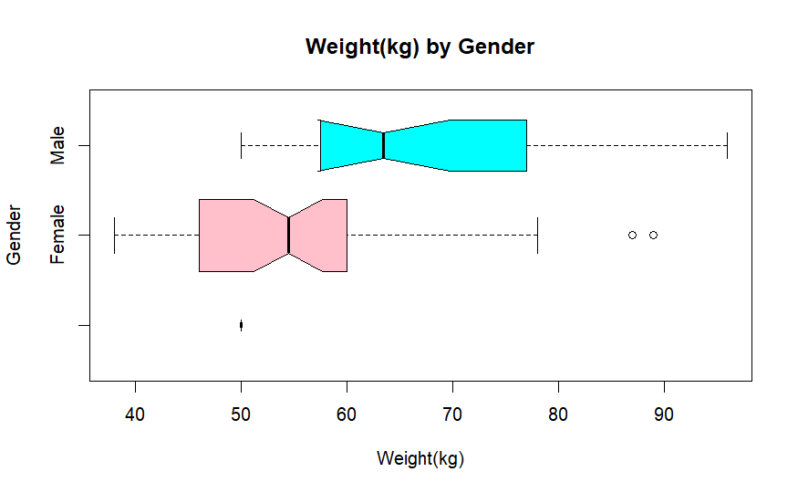

```r
boxplot(dt$weight~dt$Gender,ylab="Gender",xlab="Weight(kg)",
main="Weight(kg) by Gender", col=c("cyan","pink"),
horizontal=TRUE, notch=TRUE, varwidth = TRUE)
```

6. Scatter Plots • Scatter plots or is also known as dispersion graphs. The scatter plots are used to check the relation between two variables or three variables for 3D scatter plots. • Scatter matrix or pairwise comparison can be used to check the relationship between many variables.

Example 9.6a Scatter Plot

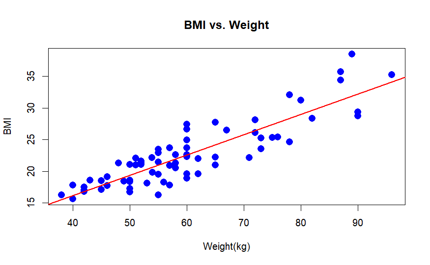

```r
## Scatter plots
plot(dt$weight,dt$bmi,xlab="Weight(kg)",ylab="BMI",
main="BMI vs. Weight", col="blue",pch=16, cex=1.5)
abline(lm(dt$bmi~dt$weight), col = "red", lwd = 2)
```

Example 9.6b 3D Scatter Plot

```r
## 3D scatter plot
library(scatterplot3d)
trees
```

| Girth | Height | Volume |
| --- | --- | --- |
| 8.3 | 70 | 10.3 |
| 8.6 | 65 | 10.3 |
| 8.8 | 63 | 10.2 |
| 10.5 | 72 | 16.4 |
| 10.7 | 81 | 18.8 |
| 10.8 | 83 | 19.7 |
| 11.0 | 66 | 15.6 |
| 11.0 | 75 | 18.2 |
| 11.1 | 80 | 22.6 |
| 11.2 | 75 | 19.9 |

[output cut: 21 more lines]

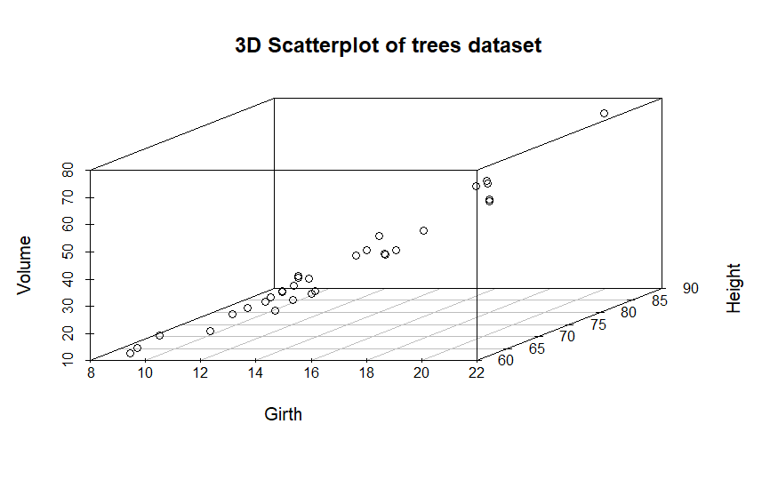

```r
attach(trees)
scatterplot3d(Girth, Height, Volume,
main = "3D Scatterplot of trees dataset")
```

Example 9.6c Scatter Plot Matrix

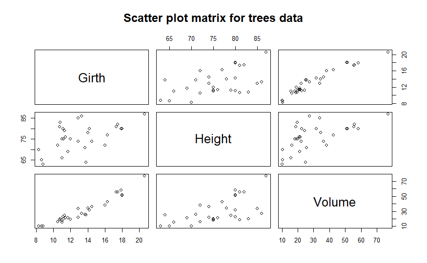

```r
#Scatter plot Matrices
pairs(trees, main = "Scatter plot matrix for trees data")
```

9.2 Graphical User Interface Development • GUI is the acronym for graphical user interface, the interface that allows users to interact with electronic devices, such as computers, laptops, smartphones and tablets, through graphical elements (icons, buttons, and menus).

• GUI is a software application programming for human-computer interaction, replacing text-based commands with user-friendly actions. Its goal is to present the user with decision points that are easy to find, understand and use. In other words, GUI lets you control your device with a mouse, pen or even your finger.

• To count as “successful” interactivity, the dashboard interface design has to be human-centric.

Dashboard and GUI Application • In information technology (IT), the term dashboard refers to a graphical user interface (GUI) that organizes and presents information in a format that is easy to read and interpret.

• In business computer information systems, a dashboard is a type of graphical user interface which often provides at-a-glance views of key performance indicators (KPIs) relevant to a particular objective or business process. In other usage, ”dashboard” is another name for ”progress report” or ”report” and considered a form of data visualization.

R packages to develop Dashboard and GUI In R, there are several packages available for developing GUI and dashboard applications. Here are a few popular ones:

1. RShiny: RShiny is a widely used R package for building web applications with interactive user interfaces. It allows you to create web-based GUIs and dashboards using R code. RShiny provides a reactive programming framework that facilitates easy integration of R code and interactive components such as sliders, input fields and plots.
2. RStudio Dashboard: RStudio provides its own set of packages for building dashboards. The flexdashboard package allows you to create flexible and interactive dashboards using R Markdown. It supports various layout options, including multiple panels, tabs, and responsive design. You can embed interactive visualizations and data-driven content in your dashboards.
3. shinydashboard: The shinydashboard package is an extension of the Shiny package and provides a framework for creating dashboards with a more structured layout. It offers predefined dashboard components such as sidebars, boxes, and tabs, which help in organizing the content of your dashboard. You can easily add interactive elements and visualizations to create dynamic dashboards.
4. RGL: If you are looking for 3D graphics capabilities in your GUI, the rgl package is a good option. It provides functions for creating interactive 3D plots, scenes, and animations. You can incorporate these 3D visualizations into your GUI or dashboard application.